# 单细胞配对数据多样本整合运行教程

XuanLiang

Compiled: July 03, 2025

在本教程中，主要讲述如何根据整合单细胞多个样本的配对数据，使用官方推荐的Seurat和Signac软件运行。这里以癌症配对的数据中BRCA为例，官方的教程可以参考文档：https://stuartlab.org/signac/articles/merging。

BRCA配对的样本总共有8个，包括HT235B1-S1H1、HT243B1-S1H4、HT263B1-S1H1、HT297B1-S1H1、HT305B1-S1H1、HT497B1-S1H1、HT514B1-S1H3和HT545B1-S1H1，每个样本按照`单细胞配对数据运行教程`运行，获得每个样本的配对Seurat对象。

## 加载所需要的包

```r
library(Seurat)
library(ggplot2)
library(patchwork)
library(dplyr)
library(Signac)
library(GenomicRanges)
library(GenomeInfoDb)
library(EnsDb.Hsapiens.v86)
```

## 创建公共峰集

按照`单细胞配对数据运行教程`处理8个样本。由于在每个实验中独立鉴定的峰可能不会完全重叠，因此我们合并了所有数据集中的峰以创建一个通用峰集。然后在合并对象之前，在每个实验中量化这个共同的峰集。

首先，我们将加载每个实验的峰坐标并将其转换为基因组范围，使用 `GenomicRanges::reduce` 函数创建一组通用的峰，以便在每个数据集中进行量化。

```r
# 读取8个单细胞多组学BRCA样本的Seurat对象
HT497B1 <- readRDS("HT497B1/HT497B1.rds")
HT235B1 <- readRDS("HT235B1/HT235B1.rds")
HT243B1 <- readRDS("HT243B1/HT243B1.rds")
HT263B1 <- readRDS("HT263B1/HT263B1.rds")
HT297B1 <- readRDS("HT297B1/HT297B1.rds")
HT305B1 <- readRDS("HT305B1/HT305B1.rds")
HT514B1 <- readRDS("HT514B1/HT514B1.rds")
HT545B1 <- readRDS("HT545B1/HT545B1.rds")

# 将每个样本的默认assay设置为“peaks”，以确保之后的peak合并基于相同的assay
DefaultAssay(HT497B1) <- "peaks"
DefaultAssay(HT235B1) <- "peaks"
DefaultAssay(HT243B1) <- "peaks"
DefaultAssay(HT263B1) <- "peaks"
DefaultAssay(HT297B1) <- "peaks"
DefaultAssay(HT305B1) <- "peaks"
DefaultAssay(HT514B1) <- "peaks"
DefaultAssay(HT545B1) <- "peaks"

# 在每个数据集中创建一组统一的峰以进行量化
combined.peaks <- UnifyPeaks(object.list = list(HT497B1, HT235B1,HT243B1,HT263B1, HT297B1,HT305B1, HT514B1, HT545B1), mode = "reduce")

# 根据长度过滤掉异常的峰
peakwidths <- width(combined.peaks)
combined.peaks <- combined.peaks[peakwidths  < 10000 & peakwidths > 20]

# 将最终得到的标准化peak集合保存为R数据文件
saveRDS(combined.peaks,file="combined.peaks.rds")

combined.peaks
```

```
## GRanges object with 332049 ranges and 0 metadata columns:
##            seqnames              ranges strand
##               <Rle>           <IRanges>  <Rle>
##        [1]     chr1         10052-10354      *
##        [2]     chr1         17357-17556      *
##        [3]     chr1       180671-181608      *
##        [4]     chr1       182656-182855      *
##        [5]     chr1       184060-184538      *
##        ...      ...                 ...    ...
##   [332045]     chrX 156008847-156009158      *
##   [332046]     chrX 156019931-156020136      *
##   [332047]     chrX 156025093-156025394      *
##   [332048]     chrX 156029775-156030685      *
##   [332049]     chrY   11107054-11107805      *
##   -------
##   seqinfo: 24 sequences from an unspecified genome; no seqlengths
```

## 量化每个数据集中的峰值

我们可以使用 `FeatureMatrix` 函数为每个样品创`peaks x cell`矩阵。此函数使用 future 包进行并行化。有关使用 future 的更多信息，请参阅 [parallelization](https://stuartlab.org/signac/articles/future) 文档。

```r
# 使用统一的combined.peaks，对每个样本生成一个稀疏计数矩阵（peak × cell）
# 该矩阵表示每个cell在每个peak区域内的ATAC-seq fragment计数
HT497B1.count<-FeatureMatrix(
  fragments = Fragments(HT497B1),
  features = combined.peaks,
  cells = colnames(HT497B1)
)

HT235B1.count<-FeatureMatrix(
  fragments = Fragments(HT235B1),
  features = combined.peaks,
  cells = colnames(HT235B1)
)

HT243B1.count<-FeatureMatrix(
  fragments = Fragments(HT243B1),
  features = combined.peaks,
  cells = colnames(HT243B1)
)

HT263B1.count<-FeatureMatrix(
  fragments = Fragments(HT263B1),
  features = combined.peaks,
  cells = colnames(HT263B1)
)

HT297B1.count<-FeatureMatrix(
  fragments = Fragments(HT297B1),
  features = combined.peaks,
  cells = colnames(HT297B1)
)

HT305B1.count<-FeatureMatrix(
  fragments = Fragments(HT305B1),
  features = combined.peaks,
  cells = colnames(HT305B1)
)

HT514B1.count<-FeatureMatrix(
  fragments = Fragments(HT514B1),
  features = combined.peaks,
  cells = colnames(HT514B1)
)

HT545B1.count<-FeatureMatrix(
  fragments = Fragments(HT545B1),
  features = combined.peaks,
  cells = colnames(HT545B1)
)
```

## 创建对象

接着，我们将使用量化矩阵为每个数据集创建一个 Seurat 对象，并在分析中存储每个数据集的 Fragment 对象。

```r
# 从EnsDb.Hsapiens.v86获取基因注释
# 在染色体名称前添加“chr”前缀，以匹配峰值命名约定
annotation <- GetGRangesFromEnsDb(ensdb = EnsDb.Hsapiens.v86)
seqlevels(annotation) <- paste0("chr", seqlevels(annotation))

# 使用标准化的 combined.peaks 和各自的 fragment 信息，构建新的 ChromatinAssay 对象
# 将其添加回 Seurat 对象中作为新的 "peaks" assay
HT497B1[['peaks']] <- CreateChromatinAssay(counts = HT497B1.count,sep = c(":", "-"),fragments = Fragments(HT497B1),annotation = annotation)
HT235B1[['peaks']] <- CreateChromatinAssay(counts = HT235B1.count,sep = c(":", "-"),fragments = Fragments(HT235B1),annotation = annotation)
HT243B1[['peaks']] <- CreateChromatinAssay(counts = HT243B1.count,sep = c(":", "-"),fragments = Fragments(HT243B1),annotation = annotation)
HT263B1[['peaks']] <- CreateChromatinAssay(counts = HT263B1.count,sep = c(":", "-"),fragments = Fragments(HT263B1),annotation = annotation)
HT297B1[['peaks']] <- CreateChromatinAssay(counts = HT297B1.count,sep = c(":", "-"),fragments = Fragments(HT297B1),annotation = annotation)
HT305B1[['peaks']] <- CreateChromatinAssay(counts = HT305B1.count,sep = c(":", "-"),fragments = Fragments(HT305B1),annotation = annotation)
HT514B1[['peaks']] <- CreateChromatinAssay(counts = HT514B1.count,sep = c(":", "-"),fragments = Fragments(HT514B1),annotation = annotation)
HT545B1[['peaks']] <- CreateChromatinAssay(counts = HT545B1.count,sep = c(":", "-"),fragments = Fragments(HT545B1),annotation = annotation)
```

## 合并对象

现在8个样本都包含具有相同特征集的分析，我们可以使用标准的 `merge` 函数合并它们。

```r
# 构造 Seurat 对象列表
seurat_list <- list(HT497B1, HT235B1, HT243B1, HT263B1, HT297B1, HT305B1, HT514B1, HT545B1)

# 对应的前缀标签
sample_ids <- c("HT497B1", "HT235B1", "HT243B1", "HT263B1", "HT297B1", "HT305B1", "HT514B1", "HT545B1")

# 使用 Map 添加 cell 前缀
for (i in seq_along(seurat_list)) {
  seurat_list[[i]] <- RenameCells(seurat_list[[i]], new.names = paste0(sample_ids[i], "_", colnames(seurat_list[[i]])))
}

# 直接 merge 所有对象
BRCA <- merge(seurat_list[[1]], y = seurat_list[-1])

# 添加 sample 标签到 metadata 中（方便后续根据样本区分细胞）
BRCA@meta.data$sample <- c(rep("HT497B1", ncol(HT497B1)), rep("HT235B1", ncol(HT235B1)),rep("HT243B1", ncol(HT243B1)),rep("HT263B1", ncol(HT263B1)),
                           rep("HT297B1", ncol(HT297B1)),rep("HT305B1", ncol(HT305B1)),rep("HT514B1", ncol(HT514B1)),rep("HT545B1", ncol(HT545B1)))
```

## 合并样本后的RNA分析

使用SCTransform对RNA数据进行归一化，并执行PCA以进行降维。

```r
# 将默认设置为“RNA”进行基于RNA的分析
DefaultAssay(BRCA) <- "RNA"

# 使用SCTransform执行归一化和方差稳定
# 取代了传统的log-normalization，识别高变基因和归一化数据，即代替了原来的三个函数：NormalizeData(), FindVariableFeatures(), ScaleData(),并将处理后的数据存放在“SCT”分析中
BRCA <- SCTransform(BRCA,vars.to.regress = c("nCount_RNA",
                                                 "percent.mt"), return.only.var.genes = F)

# 对归一化数据运行主成分分析（PCA）
# PCA在保留主要变异源的同时降低了维度
BRCA <- RunPCA(BRCA)
```

## 合并样本后的ATAC分析

识别高度可访问的峰值，并使用TF-IDF和SVD（LSI）进行降维。

```r
# 将默认测定设置为“peaks”
DefaultAssay(BRCA) <- "peaks"

# 根据可访问性确定顶部特征（峰值）；仅在至少5个细胞中保持峰值
BRCA <- FindTopFeatures(BRCA, min.cutoff = 5)

# 执行词频反向文档频率（TF-IDF）规范化
BRCA <- RunTFIDF(BRCA)

# 使用奇异值分解（SVD）进行降维，在这种情况下也称为潜在语义索引（LSI）
BRCA <- RunSVD(BRCA)
```

## 基于Harmony的批次效应矫正与多组学数据整合

采用 [Harmony](https://doi.org/10.1038/s41592-019-0619-0) 算法分别对 RNA（PCA 空间）和 ATAC（LSI 空间）数据进行批次效应校正，随后通过多模态邻接图融合两种数据模态，最终实现基于融合信息的 UMAP 可视化。

```r
# 加载 Harmony 包，用于批次效应校正
library(harmony)

# 使用 RNA assay，基于 PCA 的结果进行 Harmony 批次校正
DefaultAssay(BRCA) <- "RNA"
BRCA<-RunHarmony(BRCA,
                   group.by.vars="sample",
                   reduction.use = 'pca',
                   reduction.save = "harmony1",
)

# 使用 peaks assay，基于 LSI 空间对 ATAC 数据做批次校正
DefaultAssay(BRCA) <- "peaks"
BRCA<-RunHarmony(BRCA,
                   group.by.vars="sample",
                   reduction.use = 'lsi',
                   reduction.save = "harmony2",
                   project.dim = FALSE
)

# 使用 Harmony 处理后的 RNA (harmony1) 和 ATAC (harmony2) 降维结果构建多模态邻接图
BRCA <- FindMultiModalNeighbors(
  object = BRCA,
  reduction.list = list("harmony1", "harmony2"),
  dims.list = list(1:50, 2:40),
  modality.weight.name = "RNA.weight",
  verbose = TRUE
)

# 在上述多模态邻接图 (weighted.nn) 基础上进行 UMAP 降维可视化 (融合了 RNA 和 ATAC 信息)
BRCA <- RunUMAP(
  object = BRCA,
  nn.name = "weighted.nn",
  assay = "RNA",
  verbose = TRUE
)

# 保存当前整合后的 Seurat 对象
saveRDS(BRCA,file="BRCA.rds")
```

## 合并样本后的细胞聚类与UMAP可视化

使用SCT标准化的表达数据，基于前30个主成分构建邻接图并进行聚类，随后通过UMAP进行降维和可视化。

**注意**：这里未进行细胞注释

```r
DefaultAssay(BRCA) <- "SCT"

# 基于 RNA PCA（1:30）构建聚类所需的邻接图
BRCA <- FindNeighbors(BRCA, dims = 1:30)
```

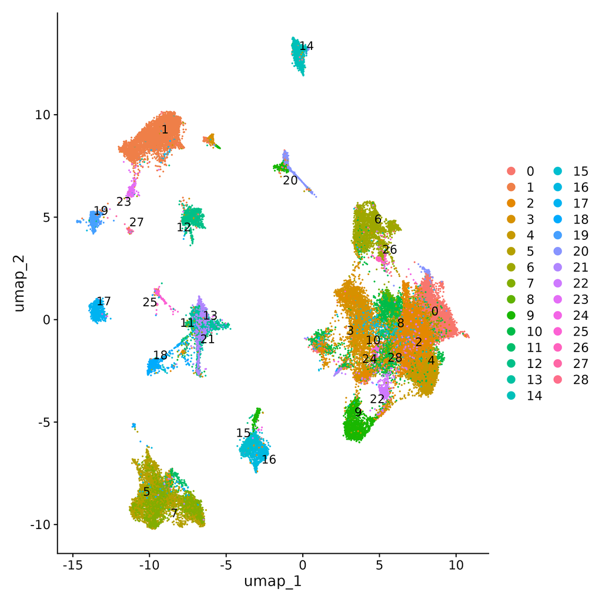

```r
# 运行图聚类（Louvain algorithm = 3 表示 Leiden 算法），resolution = 0.5 控制簇的数量
BRCA <- FindClusters(BRCA, resolution = 0.5, verbose = FALSE, algorithm = 3)

# 绘制整合后的 UMAP，显示聚类结果并避免标签重叠
DimPlot(BRCA, label = TRUE, repel = TRUE, reduction = "umap")
```